# OPT-Neuro Motion Report

This summarizes the MRIQC metrics for framewise displacement, a measure of motion, in OPT-Neuro. It is only examining resting state fMRI scans. This document does not report the quality of structural scans.

The chart below shows how the percentage of scan timepoints above the 0.5mm threshold has changed over time. Each dot represents one run in the scanner - a participant usually has two runs per timepoint. Essentially, this percentage tells us what proportion of each run has too much motion to be useful in analysis.

*The dotted vertical line* represents the *date* of the RA call (December 14, 2018) to discuss strategies to mitigate in-scanner motion.

*The solid horizontal line* at 70% represents a *cutoff* for when the resting state data become unusable due to motion (i.e., a point that lies above the solid line will probably be unsuitable for analysis).

*The dotted horizonal line* at 35% represents a *target* percentage: points below 35% provide higher quality data, and ideally sites can shift their percentages below this line.

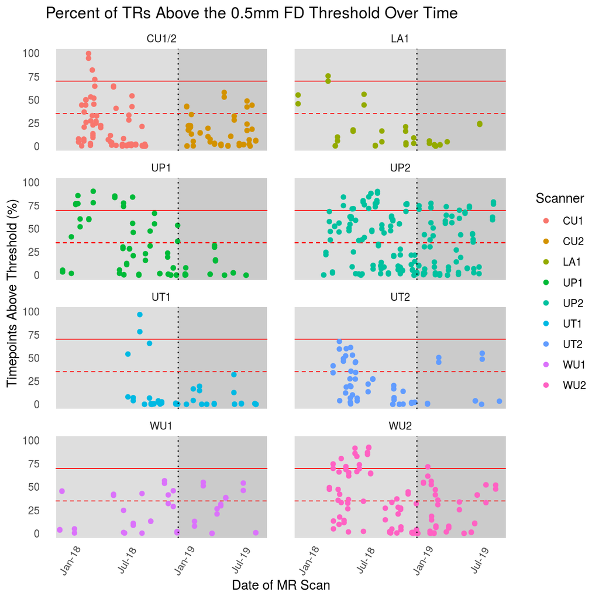

This table summarizes the median framewise displacements, as well as the median percent above threshold, for each scanner:

| Scanner | Median FD (SD) | Median FD % Above 0.5mm (SD) |
| --- | --- | --- |
| **CU** |  |  |
| CU1 | 0.19(0.23) | 9.3(25.49) |
| CU2 | 0.28(0.13) | 10.45(16.08) |
| **LA** |  |  |
| LA1 | 0.21(0.07) | 5.59(21.66) |
| **UP** |  |  |
| UP1 | 0.28(0.15) | 16.22(29.91) |
| UP2 | 0.35(0.25) | 38.11(29.29) |
| **UT** |  |  |
| UT1 | 0.17(0.32) | 0.61(20.58) |
| UT2 | 0.25(0.11) | 16.6(21.19) |
| **WU** |  |  |
| WU1 | 0.24(0.15) | 22.78(20.1) |
| WU2 | 0.29(0.15) | 27.63(28.49) |

This demonstrates how the mean framewise displacement has changed over time. Once again, the vertical dotted line represents the date of the RA meeting.

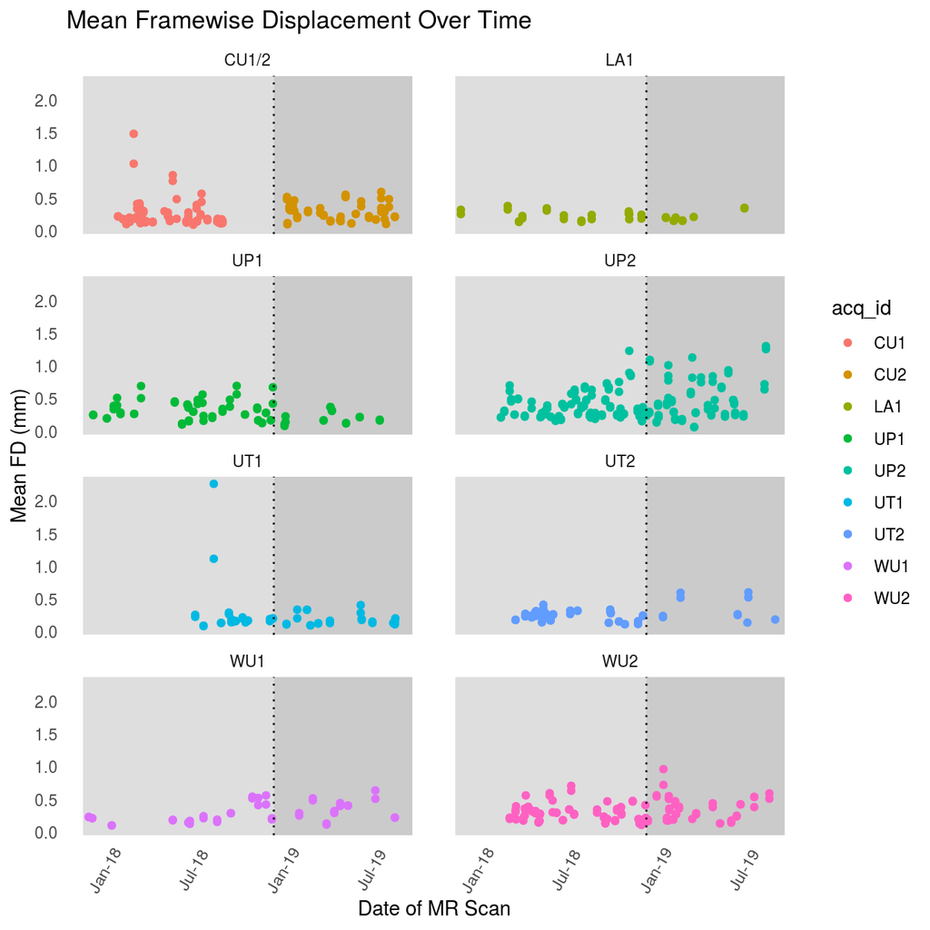